# Simulation Studies

Inference in a Closed Loop

David Smith

September 29, 2023

`./Lectures/Simulation-Studies.Rmd`

Library $\uparrow$ Nav Hub | Pseudolandia

## Summary

In Ross’s first essay on *a priori pathometry* (the term is roughly equivalent to *mathematical epidemiology,* but it didn’t catch on), he starts by giving a brief description of various kinds of epidemics [1]. He asks why epidemics should have different features, and then he asks,

> Why, indeed, should epidemics occur at all?

Epidemics are complex and difficult to study, so Ross believed some sort of mathematical theory would be required. Ross had developed simple models of malaria transmission as he played a leading role in the first decade of British Empire’s efforts to control malaria, which he wrote about in *The Prevention of Malaria* [2]. By formulating and studying those models, Ross had started down the path of developing a quantitative understanding of malaria transmission dynamics.

In the beginning, the field needed well-defined metrics to measure malaria and transmission [3]. With the potential for non-linear relationships, descriptive statistics could be misleading. Neither statistics nor models were likely to be good enough by themselves, so Ross proposed studies both ways to cross-check. In the 1916 essay on the study of epidemics, Ross wrote:

> The whole subject is capable of study by two distinct methods which are used in other branches of science, which are complementary of each other, and which should converge towards the same results – the *a posteriori* and the *a priori* methods. In the former we commence with observed statistics, endeavour to fit analytical laws to them, and so work backwards to the underlying cause (as done in much statistical work of the day) ; and in the latter we assume a knowledge of the causes, construct our differential equations on that supposition, follow up the logical consequences, and finally test the calculated results by comparing them with the observed statistics.

The relationship between reality and a set of observations is affected by the observational process, so that the *signal* of the truth might be detected through a statistical analysis. If you start with descriptive statistics and work backwards, you might be able to measure the effect of some *cause.*

Ross believed it was possible to write down systems of differential equations that described reality. Ross proposed that the two should start to converge if the mechanistic models were good enough. In this world, an investigation of epidemics required some sort of triangulation, cross checking the results using one’s intuition.

The idea of a simulation study is to invent a reality, so that the *truth* is known. In the case of a simulation study, the investigator walks through an inferential process. In reality, the truth is not known, but in a simulation study, the truth can be specified exactly. In some ways, the inferential process is trivial, because it is happening in a closed loop. An advantage of the simulation study is that it provides a way of *pressure testing* methods to learn how they could fail. The idea is not too different from the power calculations done a study is conducted. It’s a good way of testing whether the proposed statistical methods *could ever* work.

One outstanding example of a simulation study is a study by Ludgwig and Walters (1985) *Are Age-Structured Models Appropriate for Catch-Effort Data?* [4]. The question they addressed was what sort of model would work best to manage fisheries. For a broader perspective on the sorts of questions that can be addressed in this way, I recommend reading Simon Levin’s essay on the problem of relevant detail [5].

In the following tabs, we work through a couple of instructive studies. To develop and test methods for RAMP, we’ve also set up several simulation studies in *Pseudolandia*. The simulation studies we have developed there draw from more than a century of advances in malaria modeling. Ross recognized how simple and limited those models were. While Ross was interested in taking the models further, realistic models required important advances in many closely related fields. Every advance took enormous effort, and one person can only push things so far. Malaria modeling has come a long way since Ross [6].

While simulation studies are useful and instructive, they do not grapple with *all* the problems that confront an investigator when it’s not possible to close the loop. In reality, the truth is never wholly accessible to the investigator. Dealing with that involves telling a longer story, which we’ll save for another day.

## Regression

We can illustrate through a simple example. Suppose we have a linear relationship with noise ($\epsilon$):

$$y = mx + b + \epsilon,$$
where the noise is normally distributed, with variance $\sigma$:

$$\epsilon =
\mbox{rnorm}(0,\sigma).$$
We let $n$ be the number of pseudo-observations, and we can simulate a study where we are trying to measure the slope and intercept. All this is embodied in the function `ssLinMod` that returns the fitted linear model:

```r
ssLinMod = function(m=1.2, b=1, n=20, sigma = 2, plotit=F){
  x = runif(n,  0, 10)
  y = m*x + b + rnorm(n, 0, sigma)
  mod1 = lm(y~x)

  if(plotit == TRUE){
    plot(x, y, main = paste("m=", signif(coef(mod1)[2],3), ", b=", signif(coef(mod1)[1], 3)), xlim = c(0,10))
    abline(mod1)
    segments(0, b, 10, 10*m + b, col = "blue")
  }

  mod1
}
```

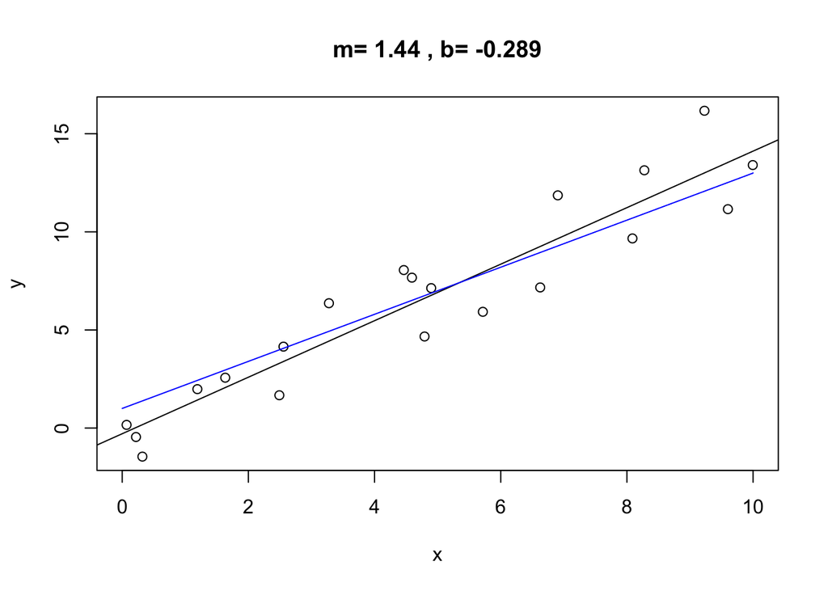

```r
ssLinMod(plotit=TRUE) -> out
```

We can easily write a function that replicates the study and returns paired estimates of the slope and intercept:

```r
ssRLinMod = function(R=100, m=1.2, b=1, n=20, sigma = 1, plotit=F){
  replicate(R, coef(ssLinMod(m, b, n, sigma))) -> out
  m_est = out[2,]
  b_est = out[1,]
  data.frame(m_est, b_est) -> out
  if(plotit==TRUE){
    par(mfrow = c(1,2))
    hist(out$m_est, main = paste("slope, m =", m), 20)
    points(m, 0, pch = 19, col = "red")
    points(mean(m_est), 0, pch = 19, col = "blue")
    hist(out$b_est, main = paste("intercept, b =",b), 20)
    points(b, 0, pch = 19, col = "red")
    points(mean(b_est), 0, pch = 19, col = "blue")
  }
  out
}
```

The red dot is the true value and the blue dot is the estimate from $R=100$ studies, each with a sample size of $n=20$. Note the scatter in the estimates.

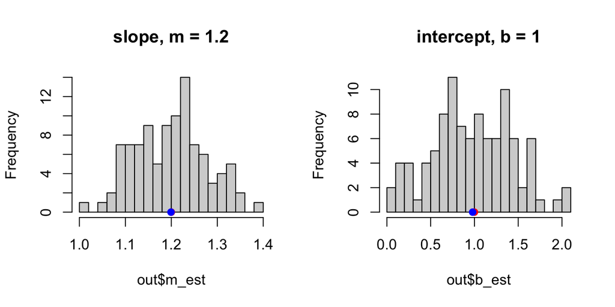

```r
ssRLinMod(100, plotit=TRUE) -> out
```

## Refs

1.

Ross R. An application of the theory of probabilities to the study of *a Priori* pathometry. Part I. Proceedings of the Royal Society A: Mathematical, Physical and Engineering Science. 1916;92: 204–230.

2.

Ross R. The Prevention of Malaria. 2nd ed. London: John Murray; 1911.

3.

Smith DL, Battle KE, Hay SI, Barker CM, Scott TW, McKenzie FE. Ross, Macdonald, and a theory for the dynamics and control of mosquito-transmitted pathogens. PLoS Pathog. 2012;8: e1002588. doi:10.1371/journal.ppat.1002588

4.

Ludwig D, Walters CJ. Are Age-Structured Models Appropriate for Catch-Effort Data? Can J Fish Aquat Sci. 1985;42: 1066–1072. doi:10.1139/f85-132

5.

Levin S. The Problem of Relevant Detail. In: Busenberg S, Martelli M, editors. Differential Equations Models in Biology, Epidemiology and Ecology: Proceedings of a Conference held in Claremont California, January 13–16, 1990. Berlin, Heidelberg: Springer Berlin Heidelberg; 1991. pp. 9–15. doi:10.1007/978-3-642-45692-3_1

6.

Reiner RC Jr, Perkins TA, Barker CM, Niu T, Chaves LF, Ellis AM, et al. A systematic review of mathematical models of mosquito-borne pathogen transmission: 1970-2010. J R Soc Interface. 2013;10: 20120921.